# Untitled

2025-06-25

# Distribución Bernoulli

$$X \sim \text{Bernoulli}(p), \quad \text{where} \quad
P(X = x) =
\begin{cases}
p & \text{if } x = 1 \\
1 - p & \text{if } x = 0 \\
0 & \text{otherwise}
\end{cases}$$

$$P(X = x) = p^x(1-p)^{1-x}, x \in \{0,1\}$$

# Variable aleatorio Binomial

Lanzando tres veces la moneda: X1 = 1 (cara), X1 = 0 (sello)

```r
X1 <- rbinom(n = 1, size = 1, prob = 0.5)
X2 <- rbinom(n = 1, size = 1, prob = 0.5)
X3 <- rbinom(n = 1, size = 1, prob = 0.5)
Y <- X1 + X2 + X3
print(Y)
```

```
## [1] 2
```

Más fácil: size: el número de experimentos.

```r
rbinom(n = 1, size = 3, prob = 0.5)
```

```
## [1] 1
```

Se tiene n experimentos INDEPENDIENTES, una probabilidad de éxito p (parámetro), la variable aleatoria Y representa el número de éxitos en los n experimentos, $Y = 0, 1, \ldots n$

```r
dbinom(x = 4,size = 10, prob = 0.6 )
```

```
## [1] 0.1114767
```

```r
choose(10,4) * ((0.6)^4) * ((0.4)^6)
```

```
## [1] 0.1114767
```

Supongamos lanzamos 10 veces la modeda:

```r
rbinom(n = 1, size = 10, prob = 0.5)
```

```
## [1] 7
```

¿Cuál es la prrobabilid de obtener en los 10 lanzamientos, menos de dos caros:

```r
choose(10, 0) * (0.6^0) * (0.4^10) + choose(10, 1) * (0.6^1) * (0.4^9)
```

```
## [1] 0.001677722
```

```r
pbinom(q = 1, size = 10, prob = 0.6)
```

```
## [1] 0.001677722
```

Calcula la probabilidad de obtener 5 o más caras en los 10 lanzamientos

$$P(X \ge 5) = 1- P(X \le 4) = 1- F(4)$$

```r
1 - pbinom(q = 4, size = 10, prob = 0.6)
```

```
## [1] 0.8337614
```

```r
 dbinom(x = 0:10, size = 10, prob = 0.6)
```

```
##  [1] 0.0001048576 0.0015728640 0.0106168320 0.0424673280 0.1114767360
##  [6] 0.2006581248 0.2508226560 0.2149908480 0.1209323520 0.0403107840
## [11] 0.0060466176
```

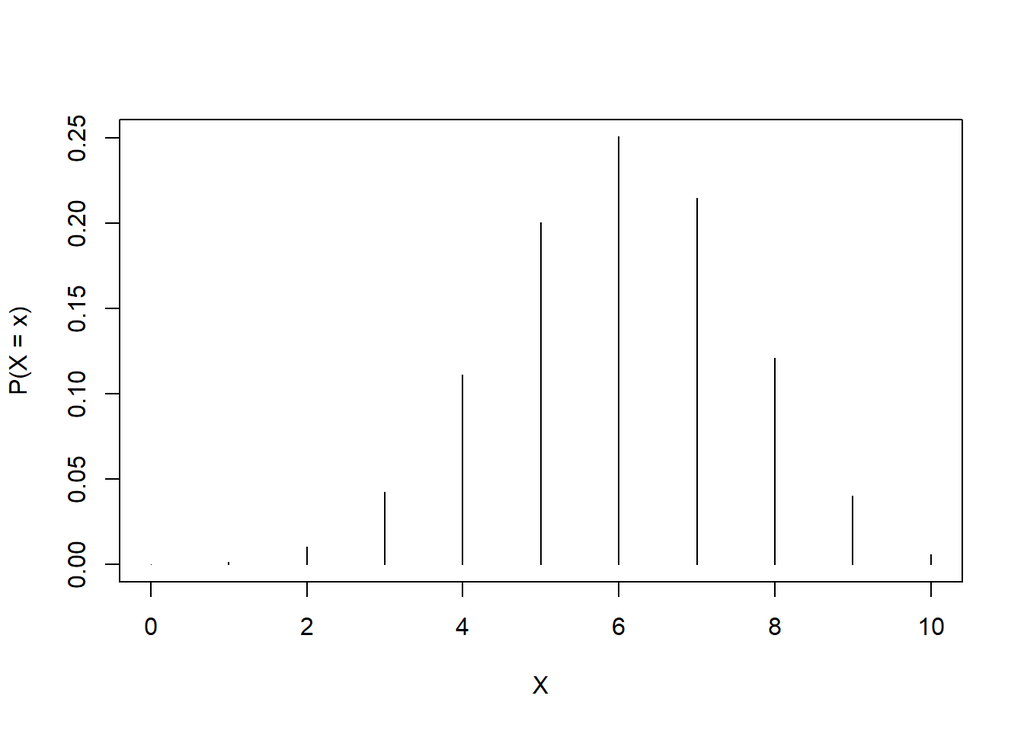

```r
plot(0:10,  dbinom(x = 0:10, size = 10, prob = 0.6), type = "h", xlab = "X", ylab = "P(X = x)")
```

Con simulación

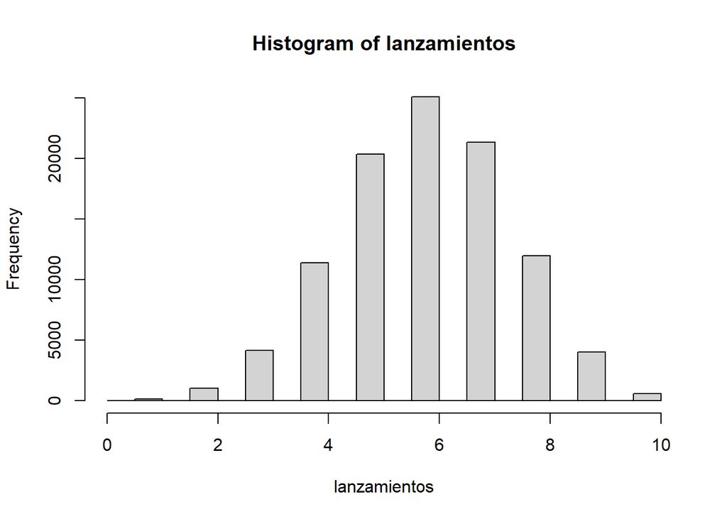

```r
lanzamientos <- rbinom(n = 100000, size = 10, prob = 0.6)
hist(lanzamientos)
```

# Valor

Pag 94,

$$E(X) = np \newline
V(X) = np(1-p)$$

Aplicación: control de calidad: un proceso industrial se dice que está bajo control si menos del 5% de los productos manafacturados tienen defectos. Un inspector de calidad utiliza la siguiente regla de control, observa una muestra cada hora de 20 productos y si encuentra al menos 1 defectuoso rechaza el lote y detiene el proceso.

¿Cuál es la probabilidad de que un lote de evaluación haga detener el proceso.

$$P(Y >= 1) = 1 - P(Y = 0)$$

```r
1 - dbinom(x = 0, size = 20, prob = 0.05)
```

```
## [1] 0.6415141
```

Que pasa si el proceso se detiene con observar dos defectuosos

$$P(Y >= 2) = 1 - P(Y = 0) - P(Y = 1) = 1-P(Y \leq 1)=1-F(1)$$

```r
1 - pbinom(q = 1, size = 20, prob = 0.05)
```

```
## [1] 0.2641605
```

# Binomial negativa

## Forma 1:

La variable aleatorio que denota el número de intentos hasta obtener K exitos se denomina la binomial negativa $x = k, k+1, ...$

$$P(X) = \binom{x-1}{k-1}p^k(1-p)^{x-k}$$
Ejercicio: si un visitador médico debe lograr dos ventas, cuál es la proabilidad de que tenga que hacer más de 5 visitas:

$$P(X \ge 5) = 1-P(x \leq 4) = 1-F(4) = 1-(P(X=2)+P(X=3)+P(X=4))$$

```r
1-(choose(1,1)*(0.4^2)*(0.6)^0 + choose(2,1)*(0.4^2)*(0.6)^1 +  choose(3,1)*(0.4^2)*(0.6)^2 )
```

```
## [1] 0.4752
```

# Segunda escritura de la binomial negativa

Sea Y como la variable aleatoria del número de fracasos que necesito antes de obtener los K éxitos, en nuestro ejemplo anterior sime pregunto por hacer 6 visitas (X = 6) antes de obtener los 2 éxitos, la variable aleatoria cuantificaría que requiero 4 fracasos (Y = 4) antes de obtener los dos éxitos (k = 2)

Y = X - K, 4 = 6 - 2

DEspejando X = Y + k 6 = 4 + 2 Visitas = fracasos + exitos

$$P(Y=y) = \binom{y+k-1}{k-1}p^k(1-p)^{y} , Y = 0, 1, ...$$

R lo hace con X como el numero de fracasos antes de X exitos Para calcula que le toma 6 visitas es por que Y = 4 (fracasos) para obtener los dos éxitos

```r
dnbinom(4, size = 2, prob = 0.4)
```

```
## [1] 0.10368
```

Es lo mismo que preguntarse por 6 visitas (X = 6) para obtener dos exitos

$$P(X) = \binom{x-1}{k-1}p^k(1-p)^{x-k}$$

```r
 choose(5,1)*(0.4^2)*(0.6)^4
```

```
## [1] 0.10368
```

$$P(Y \geq 3) = 1-P(Y\le 2)$$

```r
1-pnbinom(q = 2, size = 2, prob = 0.4) # size: k, q = 2
```

```
## [1] 0.4752
```

Ejercicio: si la probabilidad de conversión de un periodico por medio de Email Marketing (Boletin de noticias) es del 6%,

¿Cuál es la probabilidad de que requiere enviar más de 30 emails a un cliente para convertir?

Asuma que la conversión es independiente entre email e email.

X = 30, K = 1 Y = 29, K = 1

P(X > 30)

P (Y > 29)

Cuando K = 1, la binomial negativa se llama una distribución de probabilidad geométrica.

# Poisson

La variable aleatoria X cuantifica el conteos de eventos aleatorios en un intervalo de tiempo (de área, de volumen). Requiere tener el promedio de ocurrencia del fenómeno de interés en el intevalo.

Número de personas concurrentes en un sitio web, $\lambda = 16000.2$ / minuto

Numero de goles de local que hace un equipo en promedio, $\lambda = 1.8$ por partido

Número total de reclamaciones en un seguro por mes $\lambda = 22.1$ por mes

La ditribución de Poisson modela una variable aleatoria x, X = 0, 1, 2, …
$$P(x;\lambda) = \frac{\lambda^xe^{-\lambda}}{x!}$$

Ejercicio: si el número promedio de usuarios concurrentes en un evento como un temblor es de 16.000. ¿Cuál es la probabilidad de que se llegue a más de 20.000 usuarios concurrentes.

Unidades: por cada 10 mil, $\lambda = 1.6$

$$P(X > 2) = 1 - P(X <=2) = 1-P(X=0)-P(X=1)-P(X=2)$$

```r
1 - ppois(q = 2, lambda = 1.6)
```

```
## [1] 0.2166415
```

En una Poisson el valor esperado y la varianza son iguales a $\lambda$

**Ejercicio**: una prueba de laboratorio determina que en promedio sólo fallarán dos componentes de un automóvil antes de tener 1000 horas de operación. Un comprador observa que son cinco los que fallan antes de las 1000 horas, ¿existe suficiente evidencia para dudar de la conclusión del fabricante?

$$\lambda = 2, \newline ¿P(X = 5)? \newline ¿P(X \ge 5)=1- P(X \le4)?$$

```r
1-ppois(q = 4, 2)
```

```
## [1] 0.05265302
```

# Hipergeometrica

Se tiene una urna con N elementos de los cuales K son bolas blancas y N-K son bolas negras y se saca una muestra de n, la variable aleatoria X representa el número de bolas blancas en la muestra de tamaño n:

K: El número de bolas blancas en la Urna N-K: El número de bolas negras en la Urna N: el número total de bolas en la urna

x: el número de bolas blancas que salen en la muestra. n: el número de bolas que se saca en la muestra (sin reemplazo) de la urna

Ejemplo: si tengo 10 bolas blancas y 5 negras, saco una muestra de 4, ¿Cuál es la proabilidad de sacar exactamente 3 bolas blancas en la muestra?

```r
dhyper(x = 3, m = 10, n = 5, k = 4)
```

```
## [1] 0.4395604
```

```r
(choose(10, 3) * choose(5, 1)) / choose(15, 4)
```

```
## [1] 0.4395604
```

¿Cuál es la probabilidad de que obtenga menos de 3 bolas blancas:

```r
phyper(q = 2, m = 10, n = 5, k = 4)
```

```
## [1] 0.4065934
```

```r
dhyper(x = 0:4, m = 10, n = 5, k = 4)
```

```
## [1] 0.003663004 0.073260073 0.329670330 0.439560440 0.153846154
```

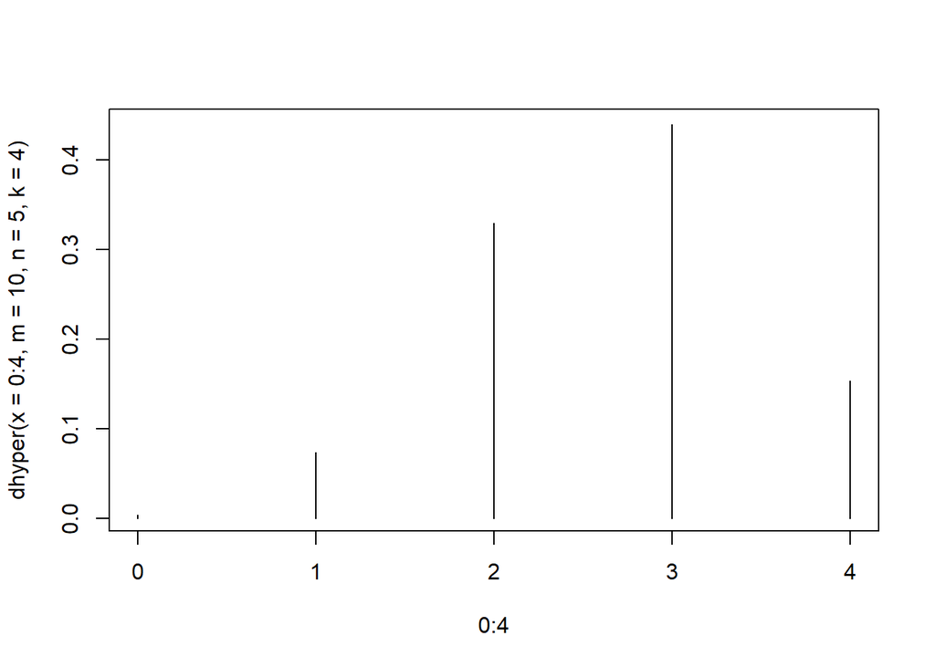

```r
plot(0:4, dhyper(x = 0:4, m = 10, n = 5, k = 4), type = "h")
```